# Calling empty droplets

Arun Chavan

Started: 2020-11-18  
Last edited: 2020-12-07 16:41:55

# 1 Setup

```r
### packages ==================================================================
library(tidyverse)
library(here)
library(ggforce)
library(ggthemes)
library(patchwork)

library(scater) # single cell
library(DropletUtils)

library(kableExtra) # knitr
```

```r
# here base
basedir <- here("species", "bflo", "10x", "run_01", "refseq__GCF_000003815.2_Bfl_VNyyK")
```

# 2 Data

```r
### read all raw feature-bc matrices ==========================================
phar <- read10xCounts(here(basedir, "data", "02_cellranger-count", "bflo_pharynx", "outs", "raw_feature_bc_matrix"), col.names = TRUE)
mdiv <- read10xCounts(here(basedir, "data", "02_cellranger-count", "bflo_midgut", "outs", "raw_feature_bc_matrix"), col.names = TRUE)
hgut <- read10xCounts(here(basedir, "data", "02_cellranger-count", "bflo_hindgut", "outs", "raw_feature_bc_matrix"), col.names = TRUE)

samples <- c("phar", "mdiv", "hgut")
```

# 3 EmptyDrops

## 3.1 Test the effect of different values of $T$ on the p-value distribution

In EmptyDrops(), first a set $G$ of barcodes $b$ is defined such that for $b \in G$, $t_{b} \le T$. Where $t_{b}$ is the total number of UMIs in barcode b, and $T$ is a threshold value. $G$ represents the set of empty barcodes that contain UMIs less than or equal to a set threshold. The exact value of $T$ does not matter, as long as (i) it is small enough that droplets containing genuine cells are not included in $G$ and (ii) large enough that there is a sufficient number of reads to create the ‘ambient profile’. A way of making sure that we are not using an inappropriate value of $T$ is to make sure that the distribution of p values is uniform for barcodes with $t_{b} < T$. This is what Lun et al did too in their paper.

```r
### test different values of T
limits <- c(25, 50, 100, 200, 400, 800)

for(i in samples){
  for(j in limits){
    set.seed(100)
    all.out <- emptyDrops(counts(get(i)), lower = j, test.ambient = TRUE)

    # create histogram
    plt.dat <- as.data.frame(all.out[all.out$Total <= j & all.out$Total > 0, ])

    assign(paste0('hist.', i, '.', j),
           ggplot(data = plt.dat, aes(x = PValue)) +
             geom_histogram(binwidth = 0.025, boundary= 0.5,
                            fill = 'grey80',
                            color = 'black',
                            size = 0.25) +
             labs(title = paste0(i, ", T = ", j)) +
             theme_minimal() +
             theme(panel.grid.minor = element_blank(),
                   panel.grid.major = element_line(size = 0.25))
    )

    # save histogram
    ggsave(get(paste0('hist.', i, '.', j)),
           filename = paste0('emptydrops_hist-pval_', i, '_', j, '.pdf'),
           path = '../results/03_emptydrops/',
           width = 4, height = 3, units = 'in')
  }
}
```

### 3.1.1 histograms for all samples for all values of $T$ tested.

#### 3.1.1.1 Pharynx

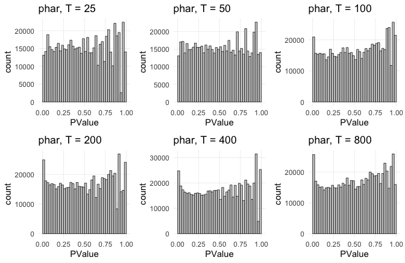

```r
gridExtra::grid.arrange(hist.phar.25, hist.phar.50, hist.phar.100, hist.phar.200, hist.phar.400, hist.phar.800, ncol = 3)
```

#### 3.1.1.2 Midgut diverticulum

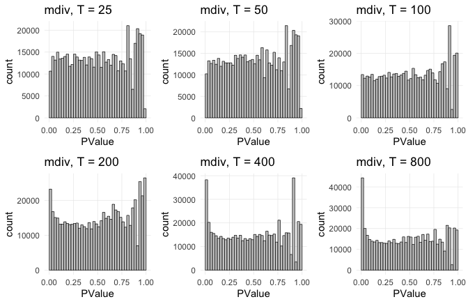

```r
gridExtra::grid.arrange(hist.mdiv.25, hist.mdiv.50, hist.mdiv.100, hist.mdiv.200, hist.mdiv.400, hist.mdiv.800, ncol = 3)
```

#### 3.1.1.3 Hindgut

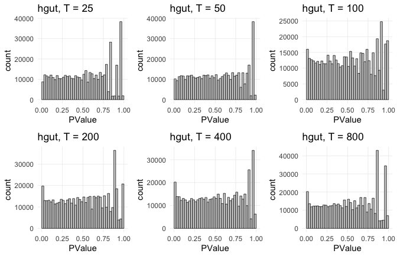

```r
gridExtra::grid.arrange(hist.hgut.25, hist.hgut.50, hist.hgut.100, hist.hgut.200, hist.hgut.400, hist.hgut.800, ncol = 3)
```

For all samples, at all values of $T$, there is a strange abundance of high p values. Those are always hard to interpret. David Robinson has a good explanation of how to interpret p value distributions on his blog [Variance Explained](http://varianceexplained.org/statistics/interpreting-pvalue-histogram/). This could happen if you are running a one-tailed test, or if your p values have already been corrected for multiple testing (not the case here, I think). But there are also pathological cases in which this can happen: when your data don’t meet certain assumptions of your tests, e.g. normality or independence. Not sure what exactly is happening here (another reason to write to Aaron Lun to clarify this).

If we ignore that end of the distribution for a minute and focus on the p values close to 0, there is a pattern. For almost all amphioxus samples, the distribution at this end is quite flat for $T = 25$ and for $T = 50$, but for values of $T > 50$, you start seeing an uptick of low p values.

This suggests that at $T > 50$, and especially at $T >= 200$, we include real cells in the ambient profile. I will proceed with $T = 50$ and $T = 100$ for running `emptyDrops` on all these samples.

## 3.2 Cell detection on all samples

Ignoring the above optimization for $T$ until I have more information, I am running `emptyDrops` on all samples.

### 3.2.1 Barcode ranks, knee, and inflection point

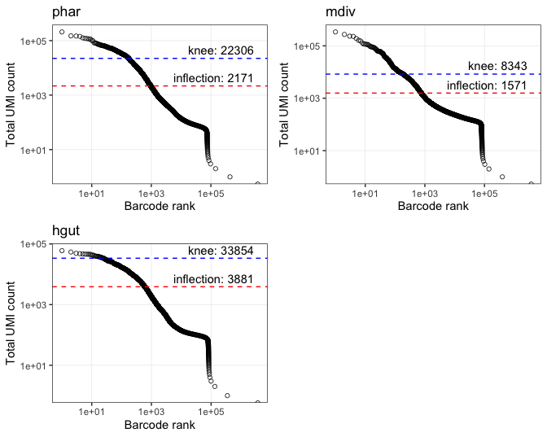

```r
### barcode ranks, knee, and inflection point =================================
# calculate barcode ranks
bcrank.phar <- barcodeRanks(counts(phar))
bcrank.mdiv <- barcodeRanks(counts(mdiv))
bcrank.hgut <- barcodeRanks(counts(hgut))

# get unique ranks for plotting speed
bcrank.phar.u <- as.data.frame(bcrank.phar) %>% unique()
bcrank.mdiv.u <- as.data.frame(bcrank.mdiv) %>% unique()
bcrank.hgut.u <- as.data.frame(bcrank.hgut) %>% unique()

# plot umi ~ bcrank
for (i in samples){
  # assign variables
  infl <- metadata(get(paste0('bcrank.', i)))$inflection
  knee <- metadata(get(paste0('bcrank.', i)))$knee
  dat <- as.data.frame(get(paste0("bcrank.", i, ".u")))

  # assing plot to brcplt.i object
  assign(paste0('bcrplt.', i),
         ggplot(data = dat, aes(x = rank, y = total)) +
           geom_point(shape = 21, alpha = 0.75) +
           scale_x_log10() +
           scale_y_log10() +
           geom_hline(yintercept = infl, color = "red", lty = 2) +
           geom_hline(yintercept = knee, color = "blue", lty = 2) +
           annotate(geom = "text", x = max(dat$rank) * 0.75, y = infl,
                    label = paste0("inflection: ", infl),
                    vjust = -0.5, hjust = 1) +
           annotate(geom = "text", x = max(dat$rank) * 0.75, y = knee,
                    label = paste0("knee: ", knee),
                    vjust = -0.5, hjust = 1) +
           labs(title = i) +
           xlab("Barcode rank") +
           ylab("Total UMI count") +
           theme_bw() +
           theme(panel.grid.minor = element_blank(),
                 panel.grid.major = element_line(size = 0.25))
  )

  # save
  ggsave(get(paste0('bcrplt.', i)),
         filename = paste0('emptydrops_bcrank_', i, '.pdf'),
         path = here(basedir, "results", "03_emptydrops"),
         width = 4.5, height = 3.5, units = 'in')
}

# print all plots for notebook
gridExtra::grid.arrange(bcrplt.phar, bcrplt.mdiv, bcrplt.hgut,
                        ncol = 2)
```

### 3.2.2 Run `emptyDrops` with $T = 100$ and $T = 200$

```r
# run emptydrops
for(i in samples){
  for(j in c(100, 200)){
    set.seed(100)
    assign(
      paste0('e.out.', i, '.', j),
      emptyDrops(counts(get(i)), lower = j)
    )
  }
}
```

Let’s make a table with number of cells called for all samples with all with both $T$ values and FDR of 0.01 (following `emptyDrops` tutorial) and FDR of 0.001 (following `osca` book).

```r
cells.called <- data.frame(
  sample = c("phar", "mdiv", "hgut"),
  t100_fdr01 = c(sum(e.out.phar.100$FDR <= 0.01, na.rm = TRUE),
                sum(e.out.mdiv.100$FDR <= 0.01, na.rm = TRUE),
                sum(e.out.hgut.100$FDR <= 0.01, na.rm = TRUE)),
  t100_fdr001 = c(sum(e.out.phar.100$FDR <= 0.001, na.rm = TRUE),
                 sum(e.out.mdiv.100$FDR <= 0.001, na.rm = TRUE),
                 sum(e.out.hgut.100$FDR <= 0.001, na.rm = TRUE)),
  t200_fdr01 = c(sum(e.out.phar.200$FDR <= 0.01, na.rm = TRUE),
                 sum(e.out.mdiv.200$FDR <= 0.01, na.rm = TRUE),
                 sum(e.out.hgut.200$FDR <= 0.01, na.rm = TRUE)),
  t200_fdr001 = c(sum(e.out.phar.200$FDR <= 0.001, na.rm = TRUE),
                  sum(e.out.mdiv.200$FDR <= 0.001, na.rm = TRUE),
                  sum(e.out.hgut.200$FDR <= 0.001, na.rm = TRUE))
)

knitr::kable(cells.called,
             col.names = c("sample", rep("cells", 4)),
             caption = "Number of cells called by `emptyDrops`",
             align = c("lrrrr")) %>%
  kable_styling(bootstrap_options = c("striped", "hover", "condensed", "responsive"),
                font_size = 12, fixed_thead = TRUE,
                full_width = FALSE) %>%
  add_header_above(c(" " = 1, # need to add an extra because df has rownames column
                     "FDR 0.01" = 1,
                     "FDR 0.001" = 1,
                     "FDR 0.01" = 1,
                     "FDR 0.001" = 1)) %>%
  add_header_above(c(" " = 1, # need to add an extra because df has rownames column
                     "T = 100" = 2,
                     "T = 200" = 2))
```

Number of cells called by `emptyDrops`

| sample | T = 100 FDR 0.01 cells | T = 100 FDR 0.001 cells | T = 200 FDR 0.01 cells | T = 200 FDR 0.001 cells |
| --- | --- | --- | --- | --- |
| phar | 5966 | 5242 | 4985 | 4690 |
| mdiv | 9243 | 189 | 2065 | 1704 |
| hgut | 4803 | 3884 | 3799 | 3439 |

1. **Only $T=200$ gives a reasonable number of cells. We’ll use that to filter.** At this setting it is not very sensitive to the FDR cutoff, but we will use 0.01.
2. The default value of $T$ in `emptyDrops` is 100. Apparently `cellranger v3` also uses `emptyDrops`, and yet, the number of cells called here by running emptyDrops is almost twice as many as reported by `cellranger`. It’s possible that `cellrnager` uses different parameters. I should email them to clarify this.

### 3.2.3 Diagnostic plots

#### 3.2.3.1 `-logProb ~ UMI` plots

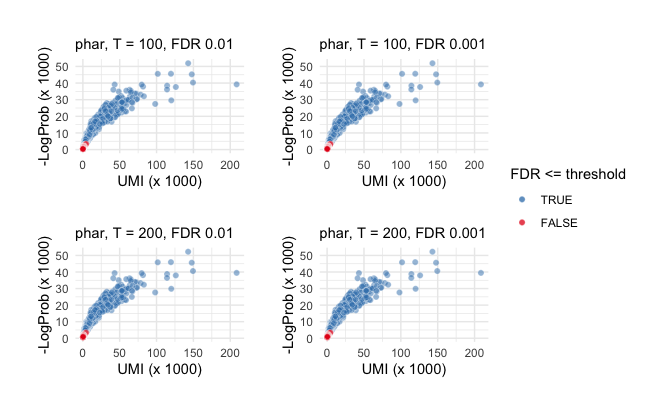

```r
# make -logProb ~ UMI count plots for for T values, and FDR 0.01 and 0.001
# Note: Using `aes(color = FDR <= k)` results in FALSE and TRUE values, and alphabetically FALSE points are plotted first and TRUE points are plotted on top. This makes the FALSE points at the bottom left not be visible at all. To change plotting order, plot them manually, with manual color assignment, and add legend manually. Instructions from here: https://aosmith.rbind.io/2018/07/19/manual-legends-ggplot2/
for(i in samples){
  for(j in c(100, 200)){
    dat <- as.data.frame(get(paste0("e.out.", i, ".", j)))
    dat <- dat[!is.na(dat$FDR), ]

    for(k in c(0.01, 0.001)){
      assign(paste0("logPplot.", i, ".", j, ".", k),
             ggplot(data = dat, aes(x = Total/1000, y = -LogProb/1000)) +
               geom_point(data = dat[dat$FDR <= k, ],
                          aes(fill = "#377EB8"),
                          alpha = 0.5, shape = 21, color = "white",
                          stroke = 0.25, size = 2) +
               geom_point(data = dat[dat$FDR > k, ],
                          aes(fill = "#E41A1C"),
                          alpha = 0.5, shape = 21, color = "white",
                          stroke = 0.25, size = 2) +
               scale_fill_identity(name = "FDR <= threshold",
                                   breaks = c("#377EB8", "#E41A1C"),
                                   labels = c("TRUE", "FALSE"),
                                   guide = "legend") +
               labs(subtitle = paste0(i,", T = ", j, ", FDR ", k)) +
               xlab("UMI (x 1000)") +
               ylab("-LogProb (x 1000)") +
               theme_minimal()
      )
    }
  }
}

# phar
logPplot.phar <- logPplot.phar.100.0.01 + logPplot.phar.100.0.001 +
  logPplot.phar.200.0.01 + logPplot.phar.200.0.001 +
  plot_layout(ncol = 2, guides = "collect") &
  theme(plot.margin = margin(0.2, 0.2, 0.2, 0.2, "in"))
ggsave(logPplot.phar,
       filename = paste0('emptydrops_logProbVsUMI_phar.pdf'),
       path = here(basedir, "results", "03_emptydrops"),
       width = 8, height = 5.5, units = 'in')
print(logPplot.phar)
```

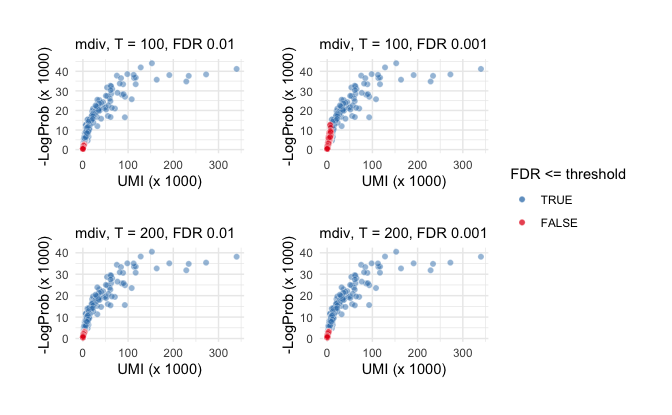

```r
# mdiv
logPplot.mdiv <- logPplot.mdiv.100.0.01 + logPplot.mdiv.100.0.001 +
  logPplot.mdiv.200.0.01 + logPplot.mdiv.200.0.001 +
  plot_layout(ncol = 2, guides = "collect") &
  theme(plot.margin = margin(0.2, 0.2, 0.2, 0.2, "in"))
ggsave(logPplot.mdiv,
       filename = paste0('emptydrops_logProbVsUMI_mdiv.pdf'),
       path = here(basedir, "results", "03_emptydrops"),
       width = 8, height = 5.5, units = 'in')
print(logPplot.mdiv)
```

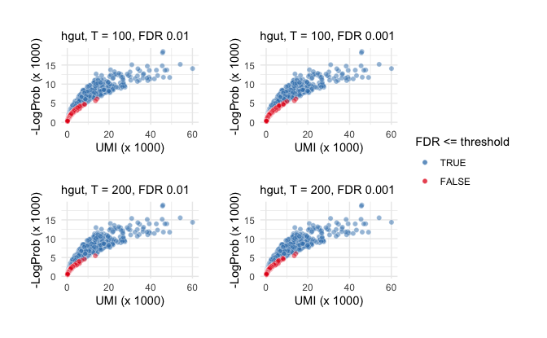

```r
# hgut
logPplot.hgut <- logPplot.hgut.100.0.01 + logPplot.hgut.100.0.001 +
  logPplot.hgut.200.0.01 + logPplot.hgut.200.0.001 +
  plot_layout(ncol = 2, guides = "collect") &
  theme(plot.margin = margin(0.2, 0.2, 0.2, 0.2, "in"))
ggsave(logPplot.hgut,
       filename = paste0('emptydrops_logProbVsUMI_hgut.pdf'),
       path = here(basedir, "results", "03_emptydrops"),
       width = 8, height = 5.5, units = 'in')
print(logPplot.hgut)
```

#### 3.2.3.2 Barcode rank plots with cell calling output

Barcode rank plots with points coloured by $FDR \le 0.01$.

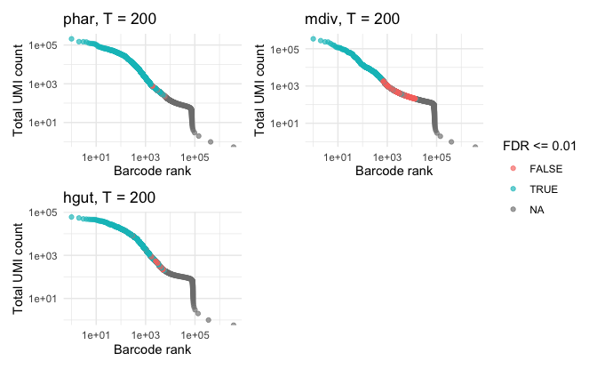

```r
# plots
for(i in samples){
  # barcode ranks (unique for plotting speed)
  bcr <- as.data.frame(get(paste0("bcrank.", i))) %>% unique()

  # emptydrops output
  ed <- get(paste0("e.out.", i, ".200"))

  # add e.out FDR values to bcrank table
  bcr$FDR <- ed$FDR[match(x = rownames(bcr), table = rownames(ed))]

  # plot
  assign(
    paste0("bcr.fdr.plt.", i),
    ggplot(data = bcr, aes(x = rank, y = total)) +
      geom_point(aes(color = FDR <= 0.01), alpha = 0.65) +
      scale_x_log10() +
      scale_y_log10() +
      labs(title = paste0(i, ", T = 200")) +
      xlab("Barcode rank") +
      ylab("Total UMI count") +
      theme_minimal()
  )

  # save
  ggsave(get(paste0('bcr.fdr.plt.', i)),
         filename = paste0('emptydrops_bcrankFDRplot_', i, '.pdf'),
         path = here(basedir, "results", "03_emptydrops"),
         width = 5.5, height = 3.5, units = 'in')
}

# for notebook
bcr.fdr.plt.phar + bcr.fdr.plt.mdiv + bcr.fdr.plt.hgut +
  plot_layout(ncol = 2, guides = "collect")
```

## 3.3 Filter data

```r
# subset SingleCellExperiment
phar.ed <- phar[, which(e.out.phar.200$FDR <= 0.01)] # `which` takes care of NAs
mdiv.ed <- mdiv[, which(e.out.mdiv.200$FDR <= 0.01)]
hgut.ed <- hgut[, which(e.out.hgut.200$FDR <= 0.01)]

# write
for(i in c("phar", "mdiv", "hgut")){
  sce.dat <- get(paste0(i, ".ed"))

  write10xCounts(
    x = counts(sce.dat),
    path =  paste0(here(basedir, "data", "03_emptydrops", "filtered_feature_bc_matrix/bflo_"), i),
    barcodes = colData(sce.dat)$Barcode,
    gene.id = rowData(sce.dat)$ID,
    gene.symbol = rowData(sce.dat)$Symbol,
    gene.type = rowData(sce.dat)$Type,
    version = "3"
  )
}
```